# LRTools Vignette

Created by Lionel Rohner

Current package version: 0.1.0.0000 (beta)

Contact: lionel.rohner@gmail.com

## Introduction

This is a small collection of the most useful functions I wrote during my master project. The package consists of functions that are necessary for the bioinformatics pipeline that I used to analyze Illumina HM450 and EPIC data. The package also includes other useful functions that can be helpful when analyzing DNA methylation data from these platforms.

## Installation & Dependecies

To install this package use : `devtools::install_github("LionelRohner/LRTools")`  
Following packages are required to use all functions of this package: `matrixStats, pwr, ChAMP, ChAMPdata, akmedoids, ggplot2` If there are errors during the installation of `ChAMP` and `ChAMPdata`, try to install these packages first using :

```
if (!requireNamespace("BiocManager", quietly = TRUE))
    install.packages("BiocManager")

BiocManager::install("ChAMP")
BiocManager::install("ChAMPdata")
```

## Functions

### Beta_To_M

Conversion of beta-values to M-values.

#### Arguments

- **beta**: A numeric variable, vector or matrix corresponding to a beta-value. Has to be between 0 and 1.

#### Return:

- Logit transform of the input beta-values: $M_i = log_2(\frac{beta_i}{1-beta_i})$

#### Examples:

```r
vecBeta <- runif(100,0,1)
vecM <- Beta_To_M(vecBeta)
head(vecM)
```

```
#> [1]  0.6043772 -0.5694364 -1.8210289 -2.2088547 -1.9543005 -1.4339887
```

### champ.load_extended

Modified champ.load function from the package.

#### Description:

This is a modification of the function “champ.load” from the package, which allows to use the Noob background correction. The original function from loads data from IDAT files to calculate intensity and produce quality control images. Furthermore, a new argument has been added that allows to load a specific sample sheet using a regular expression. This avoids the errors of the normal loading function when multiple csv files are found in the working directory. Only the new arguments are presented here. The other arguments can be found in the manual here: https://rdrr.io/bioc/ChAMP/man/champ.load.html. The modification are minor, see line 94 and 104 to 111, everything else is from the package created by Yuan Tian , Tiffany Morris , Lee Stirling , Andrew Feber , Andrew Teschendorff , Ankur Chakravarthy . is licensed under GPL-3.

#### Arguments

- **sampleSheet.csv:** An optional argument, that allows to add the name of a specific sample sheet using regular expressions.}
- **preproc:** Choice of the preprocessing method of the rgSet. To use Noob dye bias and background correction use “Noob”. The function is available in the package. Using “Raw” is the standard method and does not include background correction.}
- **dyeMethod:** To date single sample procedure of Noob (“single”) is the only choice here.}
- **directory:** See ChAMP manual.
- **method:** See ChAMP manual.
- **methValue:** See ChAMP manual.
- **autoimpute:** See ChAMP manual.
- **filterDetP:** See ChAMP manual.
- **ProbeCutoff:** See ChAMP manual.
- **SampleCutoff:** See ChAMP manual.
- **detPcut:** See ChAMP manual.
- **filterBeads:** See ChAMP manual.
- **beadCutoff:** See ChAMP manual.
- **filterNoCG:** See ChAMP manual.
- **filterSNPs:** See ChAMP manual.
- **population:** See ChAMP manual.
- **filterMultiHit:** See ChAMP manual.
- **filterXY:** See ChAMP manual.
- **force:** See ChAMP manual.
- **arraytype:** See ChAMP manual.

#### Return:

- A list including the rgSet, mSet, beta-value matrix, detection p-value matrix, and a matrix of intensity values. See manual for more detail.

#### Examples:

```r
myLoad_450K <- champ.load_extended(method = "minfi",
                                 arraytype = "450K",
                                 sampleSheet.csv ="^someSampleSheet.csv$",
                                 preproc = "Noob",
                                 dyeMethod = "single")
```

### checkBMIQ

Plot the beta distribution of Infinium I and II probes before and after BMIQ-correction.

#### Description:

This function can be used to evaluate the beta-value distribution of Infinium I and II probes before and after probe bias correction with BMIQ. Although implemented to check BMIQ performance, this function can be used to evaluate Infinium I and II probe distribution at any step of the pipeline and is also not limited to BMIQ-corrected beta-value matrices. By default, the function represents the mean density of Infinium I and II probes across all samples. It may be advisable to check for updates to and as new EPIC manifests are released from time to time.

#### Arguments

- **betaBefore:** The beta-value matrix before BMIQ correction. The rows should be CpG probes and the columns samples.
- **betaAfter:** The beta-value matrix after BMIQ correction. The rows should be CpG probes and the columns samples.
- **array:** Selection of the array type. For EPIC data use “EPIC” and everything else will be interpreted as HM450 data. By default HM450 data is assumed.
- **sampleChoice:** To check individual samples, enter a sample name as it appears in the column names. Multiple samples can be entered with regular expressions, e.g. "“aPxxx|aPyy”".

#### Return:

- No return. A plot should appear in the pane.

#### Examples:

```r
checkBMIQ(betaBefore = beta,
                    betaAfter = beta_BMIQcorrected,
                    array = "450K")
```

### cohensD_Paired

Calculate Cohen’s D effect size for paired data.

#### Description:

This function calculates Cohen’s D for paired data. The formula was taken from the package.

#### Arguments

- **meanD:** Mean of the differences between measurements}
- **sigmaD:** SD of the differences between measurements}

#### Return:

- Cohen’s D for paired data. Adapted from

#### Examples:

```r
before <- rnorm(1000, 10, 2)
after <- rnorm(1000,20, 4)
D <- before - after
meanD <- mean(D)
sigmaD <- sd(D)
cohensD_Paired(meanD = meanD,
               sigmaD = sigmaD)
```

```
#> [1] -2.236371
```

### cohensD

Calculate standard Cohen’s D effect size.

#### Description:

This function calculates Cohen’s D, an effect size measure. If sample sizes are not equal use the unbiased modifier.

- **if n $\neq$ m:** $\text{Cohen's D} = \frac{\bar{X} - \bar{Y}}{\sqrt{s^2_{pool}}}, \quad S_{pool}= \frac{((n-1)\sigma^2_X+(m-1)\sigma^2_Y)}{n+m-2}$  
  where $\bar{X}$ and $\bar{Y}$ are the mean of the groups, $\sigma^2_X$ and $\sigma^2_Y$ are the variances of the groups, $s^2_{pool}$ is the pooled variance deviation, and n and m are the sample size of group X and Y. This effect size calculation should be used when sample sizes are not equal.
- **if n = m:** $\text{Cohen's D} = \frac{\bar{X} - \bar{Y}}{\sqrt{s^2_{pool}}}, \quad S_{pool}= \frac{(\sigma^2_X+\sigma^2_Y)}{2}$

#### Arguments

- **meanA:** Mean of Group A.
- **meanB:** Mean of Group B.
- **sdA:** SD of Group A.
- **sdB:** SD of Group B.
- **nA:** Sample size of Group A.
- **nB:** Sample size of Group B.
- **unequalSampleSize:** If set to FALSE the sample size will be assumed to be equal.
- **verbose:** Extra printed information.

#### Return:

- Cohen’s D.

#### Examples:

```r
GroupA <- rnorm(1000,10, 2)
GroupB <- rnorm(1000,20, 4)

meanGroupA <- mean(GroupA)
meanGroupB <- mean(GroupB)

sigmaGroupA <- sd(GroupA)
sigmaGroupB <- sd(GroupB)

cohensD(meanA = meanGroupA,
        meanB = meanGroupB,
        sdA = sigmaGroupA,
        sdB = sigmaGroupB,
        nA = 1000, nB = 1000,
        unbiased = TRUE,
        verbose = TRUE)
```

```
#> [1] Pooled standard deviation :  3.09262256667655
#> [1] 3.216607
```

### exVarPlot

Visualize explained variance of PC-1 and PC-2 of a matrix contaning only the most variable rows.

#### Description:

To be honest, I am not entirely sure how informative this function is. I used it to see how much the explained variance of the PCs varies in the lower tail in order to choose a suitable number of the most variable CpG-probes. This number can be quite arbitrary, and if this number is in a region of the distribution that fluctuates a lot, it may be wiser to reconsider the number of most variable rows. Explained variance is calculated as the ratio of eigenvalues of PC-1 or PC-2 divided by the sum of all eigenvalues as proposed here: https://stats.stackexchange.com/questions/254592/calculating-pca-variance-explained/254598.

#### Arguments

- **mat:** A matrix of numeric values, where rows are probes, genes, metabolites, etc. and the columns are samples.
- **lowerLim:** The lower limit of the most variable row entries.
- **upperLim:** The upper limit of the most variable row entries.
- **stepSize:** The step size. By default the step size is 10.
- **onlyPC1:** Only consider PC-1. Is “FALSE” by default.

#### Return:

- A plot and a data.frame with the explained variance of PC-1 or PC-1 + PC-2 at each step.

#### Examples:

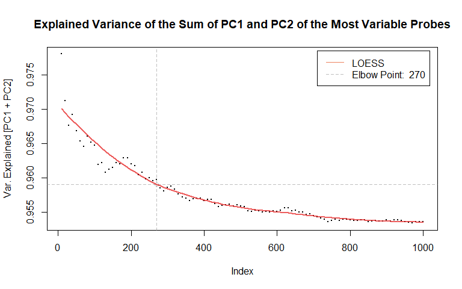

```r
A <- data.frame(rnorm(1000,0.2,0.01),runif(1000,0.2,0.75),rnorm(1000,0.75,0.05),
                          rnorm(1000,0.2,0.01),runif(1000,0.2,0.6),rnorm(1000,0.6,0.05))

rownames(A) <- paste("cg",sample(10000000:99999999,1000,replace = FALSE), sep ="")
colnames(A) <- rep(paste("Sample_",1:6,sep=""))

A <- as.matrix(A)

X <- exVarPlot(mat=A,
               lowerLim = 10,
               upperLim = 1000)
```

```r
head(X)
```

```
#>   index     varEx
#> 1    10 0.9780085
#> 2    20 0.9712260
#> 3    30 0.9676023
#> 4    40 0.9691992
#> 5    50 0.9668562
#> 6    60 0.9653772
```

### NamesDeltaBetaCut

Extraction of CpG-probes IDs or indices based on delta beta-values.

#### Description:

The purpose of this function is to find the row names or indices of the CpG probe that have a certain absolute delta beta-value difference between two groups of choice. The function is restricted to comparison of two groups.

#### Arguments

- **pd:** A - or -type sample sheet.
- **feature:** The name of the group variable as it appears in the sample sheet.
- **beta:** A beta-value matrix, where rows are CpG probes and columns are samples.
- **group1_Name:** The string representation of the factor corresponding to group 1 in the group variable “feature”.
- **group2_Name:** Same as above, but for the other group.
- **deltaBetaThreshold:** The desired delta beta-value threshold. The delta beta-value is the mean difference in beta-values between two groups. The value is converted to an absolute value. The default is 0.2.
- **returnIndeces:** By setting “returnIndices” to “TRUE” the function will return the indices of the CpG probes in the original beta-value matrix instead of the row names. Is set to “FALSE” by default.
- **sampleNames:** If the column containing the sample names in the pd is not named “Sample_Name” (ChAMP default naming convention), the column name has to be added separately. By default the function assumes the name to be “Sample_Name”.

#### Return:

- A vector containing the row names (by default the CpG-probe ID) or indices of CpG-probes that have a user-defined delta beta difference between two groups of interest.

#### Examples:

```r
# create some random matrix
A <- data.frame(runif(1000,0.2,1),runif(1000,0.3,1),runif(1000,0.5,0.99),
                runif(1000,0.1,0.7),runif(1000,0.2,0.6),runif(1000,0,0.6))

rownames(A) <- paste("cg",sample(10000000:99999999,1000,replace = FALSE), sep ="")
colnames(A) <- rep(paste("Sample_",1:6,sep=""))

pd <- cbind.data.frame(colnames(A),c(rep("Group_1",3),rep("Group_2",3)))
colnames(pd) <- c("Sample_Names","Groups")

inclusion <- NamesDeltaBetaCut(pd = pd,
                               feature = pd$Groups,
                               beta = A,
                               group1_Name = "Group_1",
                               group2_Name = "Group_2",
                               deltaBetaThreshold = 0.2,
                               returnIndeces = FALSE,
                               sampleNames = "Sample_Names")
```

```
#> Group_1 : ^Sample_1$|^Sample_2$|^Sample_3$
#> Group_2 : ^Sample_4$|^Sample_5$|^Sample_6$
```

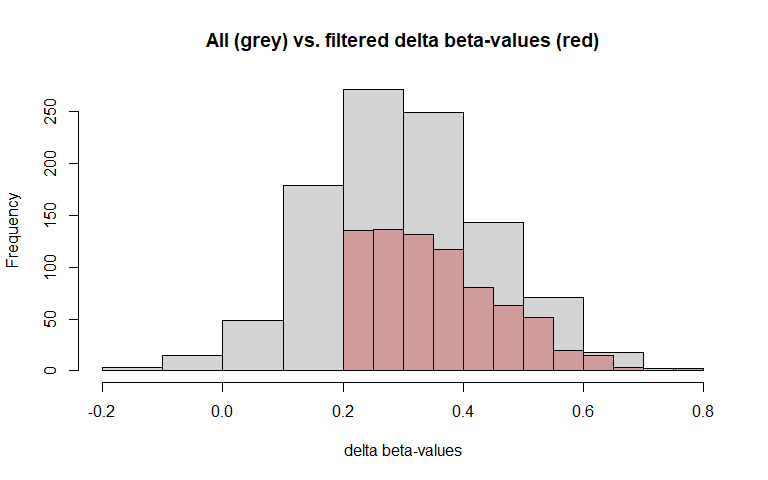

```r
# Plot results
A_filtered <- A[rownames(A) %in% inclusion,]
Group1 <- paste("^",pd[which(pd$Groups == "Group_1"), "Sample_Names"],"$",
                collapse = "|", sep = "")
Group2 <- paste("^",pd[which(pd$Groups == "Group_2"), "Sample_Names"],"$",
                collapse = "|", sep = "")

meanG1 <- rowMeans(A[,grep(Group1, colnames(A))])
meanG2 <- rowMeans(A[,grep(Group2, colnames(A))])

hist(meanG1-meanG2, xlab = "delta beta-values",
     main = "All (grey) vs. filtered delta beta-values (red)")

meanG1_filtered <- rowMeans(A_filtered[,grep(Group1, colnames(A_filtered))])
meanG2_filtered <- rowMeans(A_filtered[,grep(Group2, colnames(A_filtered))])

hist(meanG1_filtered-meanG2_filtered, col = rgb(0.8,0.1,0.1,0.3),add = TRUE)
```

### powerCalc

Power and sample size estimation.

#### Description:

The purpose of this function is to evaluate the power and estimated sample size across all CpG probes present in a beta-value or M-value matrix. The calculation of power and sample size estimation are based on the t-test functions of the package and can only be performed between features that have two levels, e.g., primary PanNET versus metastasis. PowerCalc works for normal two-group designs or paired designs. The core functions used in powerCalc are from the package created by Stephane Champely , Claus Ekstrom , Peter Dalgaard , Jeffrey Gill , Stephan Weibelzahl , Aditya Anandkumar , Clay Ford , Robert Volcic , and Helios De Rosario . is licensed under GPL (>= 3).

#### Arguments

- **betaMatrix:** A matrix of beta-values where the rows are the CpG probes and the columns are the samples.
- **pdGroups:** A - or -type sample sheet with group information, e.g. pd$Sample_Group.
- **nameGroups:** Name of the groups, e.g. c(“Met”, “Primary”).
- **alpha:** Desired alpha-significance level.
- **power:** Desired power.
- **cutOff:** The power and sample size estimation is omitted if the effect size (Cohen’s D) of a probe is less than the desired cutoff. Use this with caution as information about many CpG probes will be lost.
- **type:** Can be “paired” or “limma”. Any other string will lead to the standard two.sample t-test procedure of .
- **limmaFit:** A LMfit object with one contrast can be added to calculate the effect size based on the posterior values for the residual variances obtained from the empirical Bayes procedure.
- **pairs:** Pair information of sample sheet, e.g. pd$Pairs.
- **M:** Convert beta-values to M-values.

#### Return:

- A data.frame containing CpG probe-wise power, estimated sample size, and Cohen’s D. Depending on the type other information are included (e.g. mean and SD of the difference between 2 groups when type = "paired).

#### Examples:

```r
A <- data.frame(runif(1000,0.5,1),runif(1000,0.4,0.8),runif(1000,0.6,0.99),
                runif(1000,0.1,0.5),runif(1000,0.2,0.6),runif(1000,0,0.4))

colnames(A) <- rep(paste("Sample_",1:6,sep=""))
pd <- data.frame(c(rep("Group_1",3),rep("Group_2",3)))
colnames(pd) <- "Groups"

A <- as.matrix(A)

PC <- powerCalc(betaMatrix = A,
                type = "unpaired",
                pdGroups = pd$Groups,
                nameGroups = c("Group_1","Group_2"),
                M = TRUE,
                cutOff = 0.1)
```

```r
head(PC)
```

```
#>          M1         M2        SD1       SD2  meanDiff   CohensD         N        Power  Cohens D
#> 1 3.3528233 -0.1868609 4.70274477 0.6450534 -3.539684 -1.054583 65.038749 6.544989e-05 -1.054583
#> 2 1.8075526 -1.3700611 2.58942955 1.7695077 -3.177614 -1.432848 37.900797 2.615128e-04 -1.432848
#> 3 0.7174153 -3.4986525 0.08384345 3.5541647 -4.216068 -1.677120 29.214486 5.860689e-04 -1.677120
#> 4 2.4951157 -1.4377429 1.09287218 0.8450122 -3.932859 -4.026122  9.382203 9.320523e-02 -4.026122
#> 5 0.6614454 -1.1048238 0.59335396 1.5692378 -1.766269 -1.488900 35.527030 3.165504e-04 -1.488900
#> 6 1.7202314 -2.6177456 0.77931246 3.7336673 -4.337977 -1.608446 31.264121 4.702039e-04 -1.608446
```

### powerCalcPlot

Plotting PowerCalc Results.

#### Description:

Plotting function for powerCalc sample estimation. Generates a plot of the estimated sample size as a function of the CpG probes that have a power of 0.8.

#### Arguments

- **…:** Any data.frames produced by powerCalc.
- **sampleSizeSteps:** Estimated sample sizes for which the number of CpG-probes with power of 0.8 are calculated. Represents the range that will be plotted. By default this is “c(5,10,15,20,25,30,35,40,45,50)”.
- **returnCleanPlotObj:** Returns an empty ggplot2 object that can be modified. Is set to “FALSE” by default.
- **explicitNames:** The explicit names of the data.frames inputted in the dots argument. Maybe useful for plots shown in presentations. Assumes same order as the data.frames. Is not used by default.

#### Return:

- A plot or a ggplot object depending on returnCleanPlotObj choice.

#### Examples:

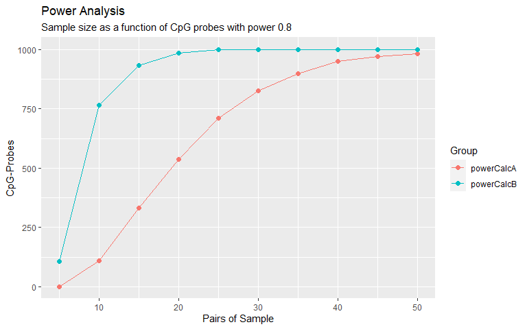

```r
# Standard Example

A <- data.frame(runif(1000,0.5,1),runif(1000,0.4,0.8),runif(1000,0.6,0.99),
                runif(1000,0.1,0.5),runif(1000,0.2,0.6),runif(1000,0,0.4))

colnames(A) <- rep(paste("Sample_",1:6,sep=""))
pdA <- data.frame(c(rep("Group_1",3),rep("Group_2",3)))
colnames(pdA) <- "Groups"

A <- as.matrix(A)

powerCalcA <-powerCalc(betaMatrix = A,
                       type = "unpaired",
                       pdGroups = pdA$Groups,
                       nameGroups = c("Group_1","Group_2"),
                       cutOff = 0.1)

B <- data.frame(runif(1000,0.8,1),runif(1000,0.8,0.9),runif(1000,0.7,0.9),
                runif(1000,0.05,0.3),runif(1000,0.2,0.3),runif(1000,0,0.3))

colnames(B) <- rep(paste("Sample_",1:6,sep=""))
pdB <- data.frame(c(rep("Group_1",3),rep("Group_2",3)))
colnames(pdB) <- "Groups"

B <- as.matrix(B)

powerCalcB <-powerCalc(betaMatrix = B,
                       type = "unpaired",
                       pdGroups = pdB$Groups,
                       nameGroups = c("Group_1","Group_2"),
                       cutOff = 0.1)

powerCalcPlot(powerCalcA, powerCalcB)
```

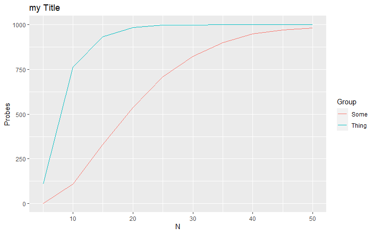

```r
# Example with returnCleanPlotObj and explicitNames

g <- powerCalcPlot(powerCalcA, powerCalcB,
                   returnCleanPlotObj = TRUE,
                   explicitNames = c("Some","Thing"))
library(ggplot2)
g + geom_line(aes(color = Group)) + labs(title = "my Title") # + etc as you like
```

### topN_variableX

Find top most variable row entries in a microarray data matrix.

#### Description:

This function can be used to extract the rows that have the greatest variance for further PCA analysis.

#### Arguments

- **mat:** A matrix with numerical values.
- **topN:** Upper bound of the number of most variable row entries. By default the 1000 most variable entries are considered.
- **plot:** Show or hide plot. Is set to “TRUE” by default.

#### Return:

- The input data.frame or matrix containing only the rows that have the highest variance in the data set.

#### Examples:

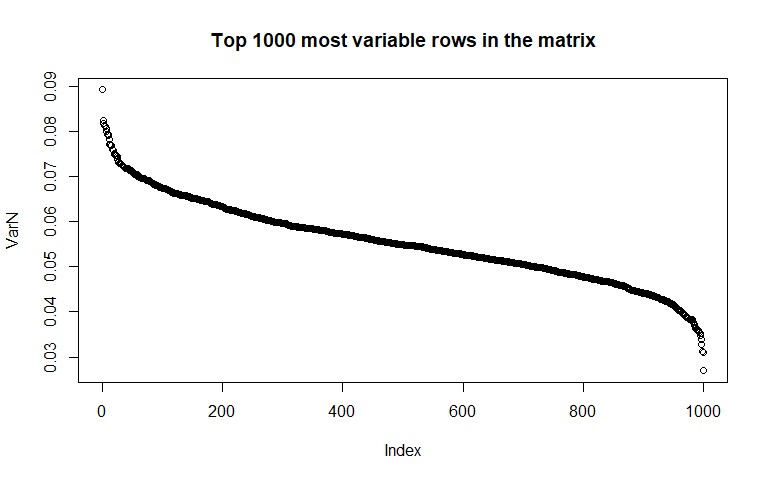

```r
A <- data.frame(rnorm(1000,0.2,0.01),runif(1000,0.2,0.75),rnorm(1000,0.75,0.05),
                          rnorm(1000,0.2,0.01),runif(1000,0.2,0.6),rnorm(1000,0.6,0.05))

rownames(A) <- paste("cg",sample(10000000:99999999,1000,replace = FALSE), sep ="")
colnames(A) <- rep(paste("Sample_",1:6,sep=""))

A <- as.matrix(A)

top1K <- topN_variableX(mat = A,
                        topN = 1000,
                        plot = TRUE)
```

```r
head(top1K)
```

```
#>             Sample_1  Sample_2  Sample_3  Sample_4  Sample_5  Sample_6
#> cg77454668 0.1991976 0.7307114 0.9478295 0.2017930 0.4085876 0.5733363
#> cg63799027 0.1863551 0.7202627 0.8056795 0.1895244 0.2100089 0.5855790
#> cg75132581 0.1885543 0.7001330 0.7995560 0.2026199 0.2257986 0.6632030
#> cg41999436 0.2133884 0.7273088 0.8920793 0.1868985 0.3641598 0.5581989
#> cg25699535 0.2039339 0.6891212 0.8250027 0.1964573 0.2426363 0.6566224
#> cg26054450 0.2129773 0.6434366 0.8540876 0.1845417 0.2232390 0.6135701
```